# rdwd use cases

### step 4: visual data checks

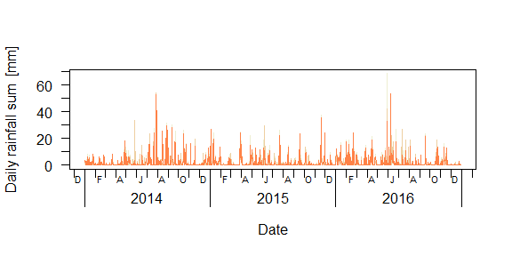

```r
plot(rain_df$date, rain_df[,2], type="n", ylim=range(rain_df[,-1], na.rm=T),
     las=1, xaxt="n", xlab="Date", ylab="Daily rainfall sum  [mm]")
berryFunctions::monthAxis()
for(i in 2:ncol(rain_df)) lines(rain_df$date, rain_df[,i], col=sample(colours(), size=1))
```

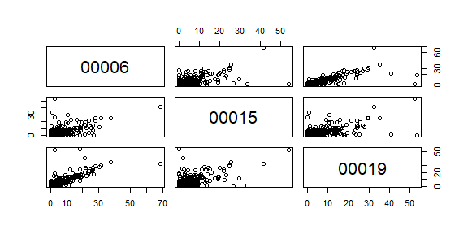

```r
plot(rain_df[,2:4]) # correlation plot only works for a few columns!
```

Let’s see the locations of our stations in an interactive map.

```r
data(geoIndex)  ;  library(leaflet)
mygeoIndex <- geoIndex[geoIndex$id %in% as.numeric(colnames(rain_df)[-1]),]

leaflet(data=mygeoIndex) %>% addTiles() %>%
        addCircleMarkers(~lon, ~lat, popup=~display, stroke=T)
```

[interactive chart not shown]

For a static map with scaleBar, OSMscale works nicely but currently still has a Java dependency, see https://github.com/brry/OSMscale#installation

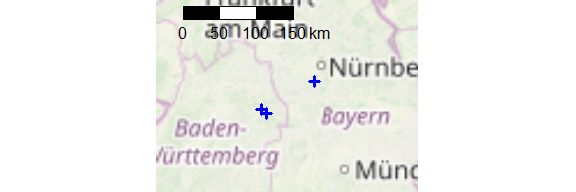

```r
library(OSMscale)
pointsMap("lat", "lon", mygeoIndex, fx=2, fy=1, pargs=list(lwd=3),
                    col="blue", zoom=5)
```

TOC

## plot all rainfall values around a given point

### 1. Find meteo stations around a given point

```r
m <- nearbyStations(49.211784, 9.812475, radius=30,
    res=c("daily","hourly"), var=c("precipitation","more_precip","kl"),
    mindate=20160530, statname="Braunsbach catchment center")
# Remove duplicates. if kl and more_precip are both available, keep only more_precip:
library("berryFunctions")
m <- sortDF(m, "var")
m <- m[!duplicated(paste0(m$Stations_id, m$res)),]
m <- sortDF(m, "res")
m <- sortDF(m, "dist", decreasing=FALSE)
rownames(m) <- NULL
head(m[,-14]) # don't show url column with long urls
```

```
##   Stations_id von_datum bis_datum Stationshoehe geoBreite geoLaenge
## 1          NA        NA        NA            NA  49.21178  9.812475
## 2        2848  19310101  20190527           458  49.25750  9.859400
## 3        5988  20180523  20190527           415  49.16380  9.916200
## 4        2787  20050101  20190527           354  49.24280  9.678600
## 5        2787  19410101  20190527           354  49.24280  9.678600
## 6        5206  20081103  20161111           396  49.11750  9.897200
##                  Stationsname         Bundesland    res           var
## 1 Braunsbach catchment center               <NA>      z          <NA>
## 2         Langenburg-Atzenrod Baden-Wuerttemberg  daily   more_precip
## 3                    Ilshofen Baden-Wuerttemberg  daily   more_precip
## 4         Kupferzell-Rechbach Baden-Wuerttemberg hourly precipitation
## 5         Kupferzell-Rechbach Baden-Wuerttemberg  daily   more_precip
## 6       Vellberg-Kleinaltdorf Baden-Wuerttemberg hourly precipitation
##          per hasfile      dist
## 1       <NA>      NA  0.000000
## 2 historical    TRUE  6.119540
## 3 historical    TRUE  9.235422
## 4 historical    TRUE 10.315219
## 5 historical    TRUE 10.315219
## 6 historical    TRUE 12.159814
```

Interactive map of just the meteo station locations:

```r
library(leaflet)
m$col <- "red" ; m$col[1] <- "blue"
leaflet(m) %>% addTiles() %>%
  addCircles(lng=9.812475, lat=49.211784, radius=30e3) %>%
  addCircleMarkers(~geoLaenge, ~geoBreite, col=~col, popup=~Stationsname)
```

[interactive chart not shown]

TOC

### 2. Download and process data

Download and process data for the stations, get the rainfall sums of a particular day (Braunsbach flood May 2016):

```r
prec <- dataDWD(m$url, fread=TRUE, dir="../localdata")
names(prec) <- m$Stations_id[-1]
prec29 <- sapply(prec[m$res[-1]=="daily"], function(x)
         {
         if(nrow(x)==0) return(NA)
         col <- "RS"
         if(!col %in% colnames(x)) col <- "R1"
         if(!col %in% colnames(x)) col <- "RSK"
         x[x$MESS_DATUM==as.POSIXct(as.Date("2016-05-29")), col]
         })
prec29 <- data.frame(Stations_id=names(prec29), precsum=unname(prec29))
prec29 <- merge(prec29, m[m$res=="daily",c(1,4:7,14)], sort=FALSE)
head(prec29[,-7]) # don't show url column with long urls
```

```
##   Stations_id precsum Stationshoehe geoBreite geoLaenge
## 1        2848   105.0           458   49.2575    9.8594
## 2        5988      NA           415   49.1638    9.9162
## 3        2787    72.0           354   49.2428    9.6786
## 4        5206    82.2           396   49.1175    9.8972
## 5        2575    94.0           426   49.1804    9.9800
## 6        3416    82.5           294   49.3423    9.8073
##                     Stationsname
## 1            Langenburg-Atzenrod
## 2                       Ilshofen
## 3            Kupferzell-Rechbach
## 4          Vellberg-Kleinaltdorf
## 5 Kirchberg/Jagst-Herboldshausen
## 6                Mulfingen/Jagst
```

TOC

### 3. Plot rainfall sum on map

For a quick look without a map, this works:

```r
plot(geoBreite~geoLaenge, data=m, asp=1)
textField(prec29$geoLaenge, prec29$geoBreite, prec29$precsum, col=2)
```

But it’s nicer to have an actual map. If OSMscale installation fails, go to https://github.com/brry/OSMscale#installation

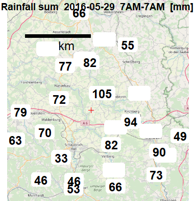

```r
library(OSMscale)
map <- pointsMap(geoBreite,geoLaenge, data=m, type="osm", plot=FALSE)
pp <- projectPoints("geoBreite", "geoLaenge", data=prec29, to=map$tiles[[1]]$projection)
prec29 <- cbind(prec29,pp) ; rm(pp)
pointsMap(geoBreite,geoLaenge, data=m, map=map, scale=FALSE)
scaleBar(map, cex=1.5, type="line", y=0.82)
textField(prec29$x, prec29$y, round(prec29$precsum), font=2, cex=1.5)
title(main="Rainfall sum  2016-05-29  7AM-7AM  [mm]", line=-1)
```

TOC

## map climate data to Landkreise

Shapefile of Landkreis districts:  
https://public.opendatasoft.com/explore/dataset/landkreise-in-germany/export/ (file size 4 MB, unzipped 10 MB)

### a) find available meteo stations for each district

```r
# Select monthly climate data:
data("metaIndex") ; m <- metaIndex
m <- m[m$res=="monthly" & m$var=="kl" & m$per=="recent" & m$hasfile, ]
# Transform into spatial object:
msf <- sf::st_as_sf(m, coords=c("geoLaenge", "geoBreite"), crs=4326)

# Read district shapefile, see link above:
lk <- sf::st_read("landkreise-in-germany.shp", quiet=TRUE)

# intersections: list with msf rownumbers for each district:
int <- sf::st_intersects(lk, msf)
```

```
## although coordinates are longitude/latitude, st_intersects assumes that they are planar
```

https://gis.stackexchange.com/a/318629/36710

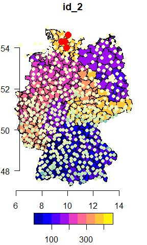

```r
# plot to check projection:
plot(lk[,"id_2"], reset=FALSE)
colPoints("geoLaenge", "geoBreite", "Stationshoehe", data=m, add=T, legend=F)
# berryFunctions::colPointsLegend + sf plots = set margins, see note there!
axis(1, line=-1); axis(2, line=-1, las=1)
points(m[int[[2]], c("geoLaenge", "geoBreite")], pch=16, col=2, cex=1.8)
```

### b) Average data per district

Running analysis for a few selected districts only to reduce computation time.  
Monthly rainfall average per Landkreis.

```r
landkreis_rain <- function(lki) # LandKreisIndex (row number in lk)
{
rnr <- int[[lki]] # msf row number
if(length(rnr)<1)
  {
  warning("No rainfall data available for Landkreis ", lki, ": ", lk$name_2[lki], call.=FALSE)
  out <- data.frame(NA,NA)[FALSE,]
  colnames(out) <- c("MESS_DATUM", as.character(lk$name_2[lki]))
  return(out)
  }
urls <- selectDWD(id=m[rnr, "Stations_id"], # set dir if needed
                  res="monthly", var="kl", per="r", outvec=TRUE)
clims <- dataDWD(urls, varnames=FALSE, quiet=TRUE, dir="../localdata")
if(length(urls)==1)
  {rainmean <- clims$MO_RR
  monthlyrain <- clims[c("MESS_DATUM", "MO_RR")]
  } else
{
monthlyrain <- lapply(seq_along(clims), function(n)
 {
 out <- clims[[n]][c("MESS_DATUM", "MO_RR")]
 colnames(out)[2] <- names(clims)[n] # no duplicate names
 out
 })
monthlyrain <- Reduce(function(...) merge(..., by="MESS_DATUM",all=TRUE), monthlyrain)
rainmean <- rowMeans(monthlyrain[,-1], na.rm=TRUE) # check also with median, variation is huge!
}
out <- data.frame(monthlyrain[,1], rainmean)
colnames(out) <- c("MESS_DATUM", as.character(lk$name_2[lki]))
return(out)
}

rainLK <- pbapply::pblapply(c(133,277,300,389), landkreis_rain)
rainLK <- Reduce(function(...) merge(..., by="MESS_DATUM",all=TRUE), rainLK)
head(rainLK)
```

```
##   MESS_DATUM Hohenlohekreis Bodenseekreis Offenbach    Berlin
## 1 2017-10-15          56.25          48.4        NA 84.183333
## 2 2017-11-15         103.40          96.7        NA 69.616667
## 3 2017-12-15          90.85          94.4        NA 39.866667
## 4 2018-01-15         124.65         114.9        NA 67.816667
## 5 2018-02-15          24.75          53.3        NA  3.183333
## 6 2018-03-15          46.75          51.1        NA 47.700000
```

TOC

Any feedback on this package (or this vignette) is very welcome via [github](https://github.com/brry/rdwd) or berry-b@gmx.de!